# Measurement error

- Show All Code
- Hide All Code
- View Source

Can it help detect ascertainment bias?

Critical analysis of a recent unblinded RCT from the NEJM

Measurement error

RCTs

biases

Author

Affiliation

[Jay Brophy](https://brophyj.github.io/)

[McGill University Dept Medicine, Epidemiology & Biostatistics](https://mcgill.ca)

Published

Monday, the 9th of November, 2026

```r
library(tidyverse)
library(knitr)
library(kableExtra)
```

## Background

On November 8 2026, the NEJM published [“Left Bundle-Branch Pacing versus Right Ventricular Pacing for Atrioventricular Block”](https://www.nejm.org/doi/full/10.1056/NEJMoa2612972?query=featured_home). This open-label, randomized, controlled trial assigned patients with atrioventricular block in a 1:1 ratio to receive left bundle-branch pacing or right ventricular pacing. The primary outcome was a composite of death from any cause, hospitalization for heart failure, or pacing-induced cardiomyopathy. At a median follow-up of 35.1 months (interquartile range, 23.6 to 40.7), the authors reported a primary-outcome event had occurred in 16 patients in the left bundle-branch pacing group and in 35 patients in the right ventricular pacing group (Kaplan–Meier 4-year cumulative incidence, 8.5% and 19.2%, respectively; hazard ratio, 0.41; 95% confidence interval, 0.23 to 0.75; P=0.003 by a stratified log-rank test). This lead the authors to conclude

**Conclusion**

“*Among patients with atrioventricular block, left bundle-branch pacing was superior to right ventricular pacing in reducing the risk of a composite of death from any cause, hospitalization for heart failure, or pacing-induced cardiomyopathy.*”

## Nuances to the conclusion

The conclusion regarding the composite outcome certainly appears well supported by the reported data and statistical testing. However, the trial was [unblinded](https://pubmed.ncbi.nlm.nih.gov/22371859/) and [stopped early](https://pubmed.ncbi.nlm.nih.gov/20332404/), features associated with exaggerated effect estimates. This matters because deaths (15 vs. 13) and heart-failure hospitalizations (2 vs. 7 as first events) were both rare and similar and the benefit thus rests on a substantial increase in unblinded, adjudicated echocardiographic cardiomyopathy (0 vs. 19). Inconsistent with this, atrial fibrillation, stroke, 6-minute walk distance, quality of life, and NYHA class did not differ between the groups. Moreover, zero cardiomyopathy events, as defined as a drop in ejection fraction of at least 10 points to below 50%, among 342 LBBP patients is surprising as temporal variability of 2D ejection fraction can exceed [10 points](https://pubmed.ncbi.nlm.nih.gov/23199515/).

Simulating five protocol mandated follow-up echo-cardiograms per patient with a measurement SD of 4 points, measurement error alone would be expected to produce about five qualifying declines, even with no true change in ventricular function (Poisson probability of zero events ≈ 0.004).

```r
## How surprising are 0 pacing-induced cardiomyopathy (PICM) events
## among 342 LBBP patients (OptimPacing, NEJM 2026)?
##
## Question: if every patient's TRUE ejection fraction were perfectly stable,
## how many would still meet the PICM echo definition through measurement
## variability alone?
## PICM definition: decrease >= 10 points from post-implant baseline,
## with resulting LVEF < 50%.
## Protocol (Table 1): pre-discharge baseline echo + 5 follow-up echoes
## (3, 6, 12, 24, 36 months).

set.seed(2026)
n      <- 342     # LBBP patients
n_fu   <- 5       # follow-up echoes per protocol
ef_mu  <- 63.2    # baseline mean LVEF, LBBP arm (Table 1)
ef_sd  <- 5.9     # observed baseline SD (includes measurement error)
nsim   <- 5000

sim_noise <- function(sd_meas) {
  sd_true <- sqrt(ef_sd^2 - sd_meas^2)   # true between-patient SD
  ev <- replicate(nsim, {
    ef_true <- rnorm(n, ef_mu, sd_true)                                 # true EF
    base    <- ef_true + rnorm(n, 0, sd_meas)                           # baseline = true + error
    fu      <- ef_true + matrix(rnorm(n * n_fu, 0, sd_meas), n, n_fu)   # 342 x 5 follow-up measurements
    sum(apply((base - fu >= 10) & (fu < 50), 1, any))
  })
  lambda <- mean(ev)                     # expected number of false events
  c(sd_meas         = sd_meas,
    p_per_patient   = lambda / n,
    expected_events = lambda,
    P0_simulated    = mean(ev == 0),
    P0_poisson      = exp(-lambda))      # Poisson P(0) = exp(-lambda)
}

res <- as.data.frame(t(sapply(c(3, 3.5, 4, 4.5, 5), sim_noise)))

kable(signif(res, 3),
      col.names = c("Measurement SD", "P(event) per patient", "Expected events",
                    "P(0 events), simulated", "P(0 events), Poisson")) |>
  kable_styling(full_width = FALSE)
## Preview image for the blog listing: must be a ggplot object, saved
## relative to this post's folder (Quarto renders from the post's directory)
p_prev <- ggplot(res, aes(sd_meas, expected_events)) +
  geom_line(linewidth = 1) +
  geom_point(size = 3) +
  geom_hline(yintercept = 0, linetype = "dashed", colour = "firebrick") +
  annotate("text", x = 3, y = 0.4, hjust = 0, colour = "firebrick",
           label = "Observed in LBBP arm: 0 events") +
  labs(x = "Echo measurement SD (LVEF points)",
       y = "Expected false PICM events (n = 342)",
       title = "Events expected from echo measurement error alone") +
  theme_minimal(base_size = 13)

ggsave("preview-image.png", p_prev, width = 8, height = 4.5, dpi = 150, bg = "white")

## Note: a 2D-echo temporal variability >10 points (Thavendiranathan et al.,
## JACC 2013) corresponds to a per-measurement SD of roughly 3.5-5 points.
## Any true intercurrent decline (ischemia, AF, valve disease) would only add
## events, so these probabilities of zero are upper bounds.
```

Table 1: Expected false-positive PICM events among 342 LBBP patients with perfectly stable true LVEF, by echo measurement SD (5000 simulations each)

| Measurement SD | P(event) per patient | Expected events | P(0 events), simulated | P(0 events), Poisson |
| --- | --- | --- | --- | --- |
| 3.0 | 0.00376 | 1.29 | 0.2810 | 2.76e-01 |
| 3.5 | 0.00870 | 2.97 | 0.0552 | 5.11e-02 |
| 4.0 | 0.01590 | 5.42 | 0.0054 | 4.41e-03 |
| 4.5 | 0.02420 | 8.28 | 0.0002 | 2.54e-04 |
| 5.0 | 0.03300 | 11.30 | 0.0000 | 1.24e-05 |

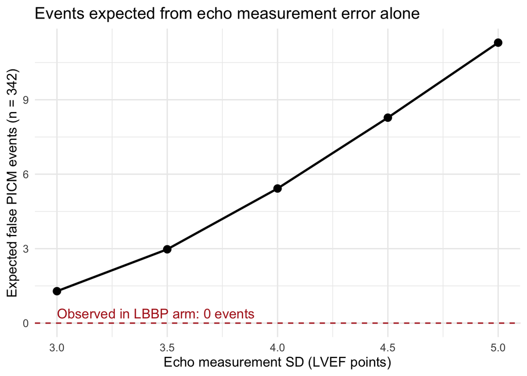

Expected number of false-positive PICM events from measurement error alone

```r
p_prev
```

Differential ascertainment or adjudication therefore seems a plausible explanation. A trial with blinded adjudication and clinical end points would seem needed.

## Lessons

I wrote this up in a Letter to the NEJM, although their 175 word format means it is impossible to articulate the fill content of this blog and explains why I bothered with this post. Yet another reason is my NEJM letters’ acceptance rate is probably less than one in five.

1. **Composite endpoints** increase statistical power but with different health impacts the individual components should also be examined
2. **Unblinded** assessments of of judgmental (soft) outcomes may be subject to unintended ascertainment bias
3. **Measurement** error is a fact of clinical research and should not be overlooked. Here measurement error paradoxically provided additional support for the existence of ascertainment bias.